# Explainable AI: The next Big thing you should know

$\hspace{1cm}$

*Alan Chau*

*DPhil in Statistical Machine Learning @ University of Oxford*

[figure not shown]

## About me

- Research: Kernel methods $\cap$ {Preferential Learning, Graph ML, Explainable AI}
- Work: Freelance Data Science and ML consultant with experiences in a variety of domain, e.g Fashion, Fintech and Agritech.
- As a human: Brewing coffee ☕ , chess ♟️ and singing 🎤.

Machine Learning is not just about prediction...

We have more ...

- Experimental design - Bayesian Optimisation
- Causal reasoning - Do-calculus
- Fair learning - Debiasing
- Data visualisation - TSNE
- Machine Learning on non-tabular data, such as text, graphs and videos - CNN, GNN
- **Explainable AI (X-AI)**

## What is Explainable AI?

$\hspace{1cm}$

- Explainable AI $\Rightarrow$ Model Inspection and interpretation techniques.
- A few reasons from *Samek et al (2017)* summarising why we should care:
  1. Verification of the system - cannot trust without knowing how this model is working under the blackbox
  2. Improvment of the system - tunning and improvement can be made if we know how it "thinks"
  3. Learning from the system - think of those human unimaginable steps proposed by AlphaGo.
  4. Compliance to legislation - GDPR "Right to explanation"
- **Be a responsible ML user**

### Example of why XAI is important

# Three areas in XAI that I find applicble all the time as a DS/ML consultant

1. Quantifying uncertainty in predictions
   - *Gaussian Processes*
2. Attributing importance scores to features
   - *Shapley Additive Explanations (SHAP)*
3. Handling what-if situations
   - *Counterfactual explanation guided by prototypes*

## Heads up ⚠️⚠️⚠️

- Target audiences for this talk are OSGDigital consultants with a good fundamental understanding of Machine Learning.
- This is not a rigorous academic talk as I will mainly focus on delivering the concepts. Demonstration will be included to showcase how straightforward it is to apply such methods in practice.
- Feel free to email me if you want more in-depth discussion afterwards.

### Let us begin.

## Quantifying your uncertain prediction using Gaussian Process

[figure not shown]

### Definition

We say $f \sim GP(m, k)$ is a Gaussian Process with mean function $m$ and covariance function $k$ if for any finite collections of data $\{X_t\}_{t=1}^n$, the vector $\mathbf{f}= [f(X_1), ... ,f(X_n)]^\top$ is a multivariate normal distribution:

\begin{equation} \mathbf{f} \sim N(\mathbf{m}, \mathbf{K}) \end{equation}

where,

\begin{align} {\bf m} &= [m(X_1), ..., m(X_n)]^\top \\ {\bf K}_{i,j} &= k(X_i, X_j) \end{align}

is the evaluated mean and covariance structure using the data $\{X_t\}_{t=1}^n$.

### Gaussian Process Regression

Given dataset $D_1 = \{(x_i, y_i)\}_{i=1}^n$, similar to how we postulate a model for linear regression:

\begin{equation} {\bf y} = {\bf X}\beta + \epsilon \quad \epsilon \sim N(0, \sigma^2) \end{equation}

where $\bf X$ is the design matrix of size $n\times d$ and ${\bf y}$ is the vector of outputs. We do the same for Gaussian Process Regression (GPR) and set:

\begin{align} {\bf y} = {\bf f} + \epsilon \quad \epsilon \sim N(0, \sigma^2 I) \end{align}

with $\mathbf{f}= [f(X_1), ... ,f(X_n)]^\top$. Using linearity of Gaussian distributions, we have $p({\bf y}) \sim N(0, K+\sigma^2I)$

### Inference

We now have complete specification of the two distributions $p(y)$ and $p(f)$ and we can apply the Gaussian conditioning rule (or bayes rule in general):

#### Gaussian conditioning

Let $\mathbf{z} \sim \mathcal{N}(\mu, \Sigma)$ be a multivariate normal random vector and let us split its dimensions into two parts, i.e.

$$ \mathbf{z}=\left[\begin{array}{l} \mathbf{z}_{1} \\ \mathbf{z}_{2} \end{array}\right], \quad \mu=\left[\begin{array}{l} \mu_{1} \\ \mu_{2} \end{array}\right], \quad \Sigma=\left[\begin{array}{ll} \Sigma_{11} & \Sigma_{12} \\ \Sigma_{21} & \Sigma_{22} \end{array}\right] $$

Note that $\Sigma_{21}=\Sigma_{12}^{\top}$ due to symmetry of covariance matrices. Then the conditional density of $\mathbf{z}_{2}$ given $\mathbf{z}_{1}$ is also normal and given by

$$ p\left(\mathbf{z}_{2} \mid \mathbf{z}_{1}\right)=\mathcal{N}\left(\mathbf{z}_{2} ; \mu_{2}+\Sigma_{21} \Sigma_{11}^{-1}\left(\mathbf{z}_{1}-\mu_{1}\right), \Sigma_{22}-\Sigma_{21} \Sigma_{11}^{-1} \Sigma_{12}\right) $$

### TL:DR

and as a result, we have

\begin{equation} \left[\begin{array}{l} \mathbf{f} \\ \mathbf{y} \end{array}\right] \sim \mathcal{N}\left(\left[\begin{array}{l} 0 \\ 0 \end{array}\right],\left[\begin{array}{ll} \mathbf{K} & \mathbf{K} \\ \mathbf{K} & \mathbf{K}+\sigma^{2} I \end{array}\right]\right) \end{equation}

and

\begin{equation} \mathbf{f} \mid \mathbf{y} \sim \mathcal{N}\left(\mathbf{K}\left(\mathbf{K}+\sigma^{2} I\right)^{-1} \mathbf{y}, \mathbf{K}-\mathbf{K}\left(\mathbf{K}+\sigma^{2} I\right)^{-1} \mathbf{K}\right) \end{equation}

where we use the mean for prediction and use the variances as uncertainty quantification.

## Should you present these to your client?....

[figure not shown]

## You need a balance between technical juices and plain english.

[figure not shown]

```python
# Load Pacakges
import numpy as np
import matplotlib.pylab as plt
import seaborn as sns

from sklearn.gaussian_process import GaussianProcessRegressor
from sklearn.gaussian_process.kernels import RBF, WhiteKernel
```

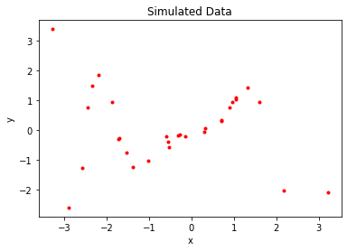

```python
# Simulate some data
n, noise = 30, 0.2
x, y = generate_GP_simulation(n, noise)

plt.plot(x, y, "r.")
plt.xlabel("x"), plt.ylabel("y"), plt.title("Simulated Data")
plt.show()
```

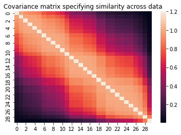

```python
# Set up the kernel function
kernel_ = RBF(length_scale=2.) + WhiteKernel(noise_level=noise)

# Visualise the kernel matrix
K = kernel_(x.reshape(-1, 1))
sns.heatmap(K)
plt.title("Covariance matrix specifying similarity across data")
plt.show()
```

### Fitting a GPR in sklearn is easy!

```python
# Set up the GPR object and fit
gpr = GaussianProcessRegressor(kernel=kernel_)
gpr.fit(x.reshape(-1, 1), y)
```

```
GaussianProcessRegressor(alpha=1e-10, copy_X_train=True,
                         kernel=RBF(length_scale=2) + WhiteKernel(noise_level=0.2),
                         n_restarts_optimizer=0, normalize_y=False,
                         optimizer='fmin_l_bfgs_b', random_state=None)
```

### Retreiving predictions and uncertainties are also easy!

```python
# Set up x_test
x_test = np.linspace(np.min(x)-2, np.max(x)+2, 300)

# Run your prediction and retrieve the mean and uncertainity
y_pred, y_std = gpr.predict(x_test.reshape(-1, 1), return_std=True)
```

### Finally, let us obtain a visualisation

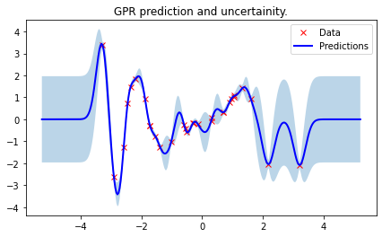

```python
# Visualisation
plot_result(x, y, x_test, y_pred, y_std)
```

## GP Summary

1. A flexible regression method (can do classification too)
2. Provides uncertainity estimation to your predictions.
3. However, these extra functionalities come with a price to pay: need $O(n^3)$ to run exact GPR. (There are ways around it though).

P.S **sklearn** is just a quick way to implement GP but one should really learn how to use **gpytorch** instead.

Short QnA time

## Quantifying feature importance: SHAP

[figure not shown]

Image credit: Scott Lundberg

## SHAP (Shapley Additive exPlanation)

- SHAP is a game theoretic approach to quantify feature's contribution to the output of **any** machine learning model.
- The idea stems from cooperative game theory in which we want to quantify how important a player is in a cooperative game.
- It relates to optimal credit assignment and it is "fair" with respect to several very reasonable axioms, such as *Linearity, Null-player property and Additivity*

## Origin story

Given a value function $v$ that takes in any combination of players $\mathcal{I} = \{1, ..., m\}$ and output some scores. What shoul we do to quantify the importance of player $i$?

Shapley (1953) proposed we do the following:

1. Fix a set of collaborators, e.g $S = \{1, 3, 5\}$ and compute the marginal improvement when player $i$ is included in the game with $S$,

\begin{align} \delta_i(S) = v(S\cup i) - v(S) \end{align}

1. Loop through all possible sets of collaborators S from the power set of $\mathcal{I} \backslash \{i\}$ and compute $\delta_i(S)$
2. Compute the weighted average :

\begin{align} \phi_i = \sum_{S \subseteq \mathcal{I}\backslash \{i\}} p_{|\mathcal{I}|, |S|} \delta_i(S) \quad \quad p_{|\mathcal{I}|, |S|} = \frac{1}{{|\mathcal{I}|-1 \choose |S|}} \end{align}

where the weight is a function of the number of players and the number of collaborators. $\phi_i$ is known as the $\textbf{Shapley Value}$ of player $i$.

## Connection to Machine learning models

To represent machine learning models as collaborative games we need to clarify the following:

1. Who are the players?
2. What is the value function?

### Players

- features $\Omega = \{1, .., m\} $used in prediction

### Value functions

For a given function $f: x \mapsto f(x)$,

- $v(S) = \mathbb{E}[f(X)|S] \quad S \subseteq \Omega$

where conditioning on $S$ means considering the input X to be a random variable where features in $S$ are known. In fact, different choices of the value functions will lead to different interepration of the importance score.

## Alternatives?

There are different feature importance scoring techniques, for example:

1. Examining coefficients of a linear model (Linear regression)
2. Looking at the frequency of being included as a splitting criteria for tree models (Random forest)
3. Examine the lengthscale in the ARD kernel (Kernel Methods)

However, these are all global scores, meaning they cannot provide local feature importance.

- e.g. For a given patient, which biomarker contributed most to estimating his organ failure in 2 months?

## Shapley Values are principled.

Shapley values are well studied objects for almost half a decade because it possess some very "nice" properties. One that is particular appealing to us is the fact that: For a given input $x$,

\begin{align} \sum_{j=1}^m \phi_j = f(x) \end{align}

the sum of feature importance equates the model prediction.

[figure not shown]

## Computing Shapley Values effectively

- In 2017, Lundberg et. al proposed KernelSHAP, a computationally effective algorithm to compute Shapley values as the solution weighted least square problem.

[figure not shown]

# Demo time: Boston Housing dataset

This dataset contains housing information in the Boston area. The goal is to predict the house price using the following features:

- CRIM: per capita crime rate by town
- ZN: proportion of residential land zoned for lots over 25,000 sq.ft.
- INDUS: proportion of non-retail business acres per town
- **RM: average number of rooms per dwelling**
- AGE: proportion of owner-occupied units built prior to 1940
- DIS: weighted distances to five Boston employment centres
- RAD: index of accessibility to radial highways
- TAX: full-value property-tax rate per USD10,000
- PTRATIO: pupil-teacher ratio by town
- B: 1000(Bk - 0.63)^2 where Bk is the proportion of blacks by town
- **LSTAT: % lower status of the population**

```python
# Import packages
import numpy as np
import matplotlib.pylab as plt

# This is the key
import shap

from sklearn.ensemble import RandomForestRegressor
```

```python
shap.initjs()

X, y = shap.datasets.boston()

rf = RandomForestRegressor(n_estimators=500)
rf.fit(X, y)

explainer = shap.KernelExplainer(rf.predict, shap.sample(X, 10))
shap_values = explainer.shap_values(X.iloc[:30,:], nsamples=50)
```

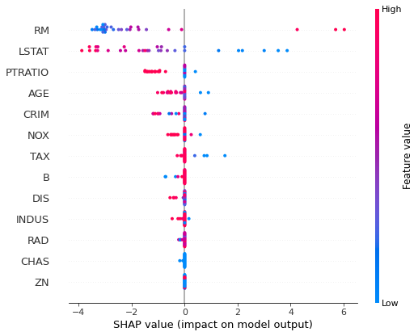

```python
shap.summary_plot(shap_values, X.iloc[:30, :])
```

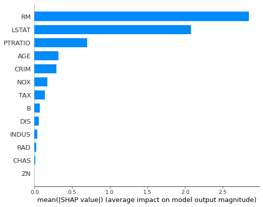

```python
shap.summary_plot(shap_values, X.iloc[:30, :], plot_type="bar")
```

## Our clients do not need to know that much detail

Here's a slide I made for the marketing team to promote a product that uses SAGE, an extension of SHAP to global feature quantification.

[figure not shown]

Short QnA time

## Handling what-if situations: Counterfactual explanations guided by prototypes

[figure not shown]

Image credit: Looveren et al (2019), *Intrepretable Counterfactual Explanations Guided by Prototypes.*

## Another nice slide

[figure not shown]

## CF as the next step

- "*What do I need to change for the company to accept my application?*"
- "*Which symptoms would lead to a different medical diagnosis?*"
- Example of counterfactual instances can give powerful insights of what is essential to the underlying decision process of the **machine** thus leading to better **human** decisions.

## What are counterfactuals?

- Mathematical Formulation: Given $f: x \mapsto f(x)$, our goal is to find a small pertubation $\delta$, such that:
  1. The model prediction on $x_{cf} := x_0 + \delta$ need to be close to the predefined output.
  2. The pertubation $\delta$ changing the original instance $x_0$ should be sparse.
  3. The counterfactual $x_{cf}$ needs to be interpretable. Menaing if $f(x_{cf})$ belongs to class $i$, then $x_{cf}$ should be close to those instances whom also belongs to class $i$.

## Formulating as optimisation

- Given the above formulation, we can phrase the search of a countefactual as an optimisation:

\begin{equation} \min_\delta c\cdot f_\kappa(x_0, \delta) + f_{dist}(\delta) \end{equation}

- where $f_\kappa(x_0, \delta)$ encorages the predicted class $i$ of the pertubed instance $x_{cf}$ to be different than the predicted class $t_0$ of the original instance $x_0$.
- the term $f_{dist}$ minmises the distance between $x_0$ and $x_{cf}$ with the aim to generate sparse counterfactuals.

### Choices of loss functions:

$\hspace{1cm}$ \begin{align} L_{pred} &:= f_{\kappa}(x_0, \delta) \\ &= \max\Big([f_{pred}(x_0 + \delta)]_{t_0} - \max_{i \neq t_0}[f_{pred}(x_0 + \delta)]_i, -\kappa\Big) \\ f_{dist}(\delta) &= \beta \cdot ||\delta||_1 + ||\delta||_2^2 \\ &= \beta \cdot L_1 + L_2 \end{align}

- the second lost is the popular elastic net regulariser.
- In practice, we append two extra loss functions to make sure our counterfactual instances are interpretable.

\begin{align} L = c\cdot L_{pred} + \beta\cdot L_1 + L_2 + L_{AE} + L_{proto} \end{align}

- where $L_{AE}$ is the $L_2$ reconstruction error of $x_{cf}$ evaluated by an autoencoder $AE$
- and $L_{proto}$ guide the pertubation to be close to the distribution of the desired counterfactual class $i$.

## Applying CF to boston housing problem:

- Our main question now is:

"Which variables need to be changed to increase or decrease a house price above or below the median value?"

```python
import numpy as np
import tensorflow as tf
from tensorflow.keras.layers import Dense, Input
from tensorflow.keras.models import Model, load_model
from tensorflow.keras.utils import to_categorical

import matplotlib.pylab as plt

from sklearn.datasets import load_boston
from alibi.explainers import CounterFactualProto

print('TF version: ', tf.__version__)
print('Eager execution enabled: ', tf.executing_eagerly())
```

```
TF version:  2.2.0
Eager execution enabled:  False
```

## Preprocessing

```python
data, target, feature_names = boston_preprocessing()

# Standarise data
mu, sigma = data.mean(axis=0), data.std(axis=0)
data = (data - mu)/sigma

# Train-Test split
idx = 475
x_train,y_train = data[:idx,:], y[:idx]
x_test, y_test = data[idx:,:], y[idx:]
y_train = to_categorical(y_train)
y_test = to_categorical(y_test)
```

### Train model

```python
def nn_model():
    x_in = Input(shape=(12,))
    x = Dense(40, activation='relu')(x_in)
    x = Dense(40, activation='relu')(x)
    x_out = Dense(2, activation='softmax')(x)
    nn = Model(inputs=x_in, outputs=x_out)
    nn.compile(loss='categorical_crossentropy', optimizer='sgd', metrics=['accuracy'])
    return nn
```

```python
nn = nn_model()
nn.summary()
nn.fit(x_train, y_train, batch_size=64, epochs=500, verbose=0)
```

```
WARNING:tensorflow:From /Users/alan/opt/anaconda3/lib/python3.7/site-packages/tensorflow/python/ops/resource_variable_ops.py:1666: calling BaseResourceVariable.__init__ (from tensorflow.python.ops.resource_variable_ops) with constraint is deprecated and will be removed in a future version.
Instructions for updating:
If using Keras pass *_constraint arguments to layers.
Model: "model_2"
_________________________________________________________________
Layer (type)                 Output Shape              Param #
=================================================================
input_1 (InputLayer)         [(None, 12)]              0
_________________________________________________________________
dense_6 (Dense)              (None, 40)                520
_________________________________________________________________
dense_7 (Dense)              (None, 40)                1640
_________________________________________________________________
dense_8 (Dense)              (None, 2)                 82
=================================================================
Total params: 2,242
Trainable params: 2,242
Non-trainable params: 0
_________________________________________________________________
```

```
<tensorflow.python.keras.callbacks.History at 0x7f8f5aa3ab90>
```

```python
# Evaluation
score = nn.evaluate(x_test, y_test, verbose=0)
print('Test accuracy: ', score[1])
```

```
Test accuracy:  0.83870965
```

```python
# Generate counterfactual
X = x_test[1].reshape((1,) + x_test[1].shape)
shape = X.shape
```

```python
tf.compat.v1.disable_eager_execution()
# initialize explainer, fit and generate counterfactual
cf = CounterFactualProto(nn, shape, use_kdtree=True, theta=10., max_iterations=1000,
                         feature_range=(x_train.min(axis=0), x_train.max(axis=0)),
                         c_init=1., c_steps=10)

cf.fit(x_train)
explanation = cf.explain(X)
```

```python
print(f'Original prediction: {explanation.orig_class}')
print('Counterfactual prediction: {}'.format(explanation.cf['class']))
```

```
Original prediction: 0
Counterfactual prediction: 1
```

```python
# Examine the explanation
explanation['cf']
```

```
{'X': array([[ 0.14638431, -0.48772237,  1.0159991 ,  0.51229566,  0.28402796,
          0.47739884, -0.7081777 ,  1.6612452 ,  1.5309265 ,  0.80657583,
          0.43348652,  0.12245432]], dtype=float32),
 'class': 1,
 'proba': array([[0.4991396, 0.5008604]], dtype=float32),
 'grads_graph': array([[10.067087  ,  0.45330763, -3.8500583 ,  6.8372397 , -2.7101579 ,
         12.737091  , -7.295387  , -6.5680256 ,  5.241354  , -3.100243  ,
         -5.456387  , 13.569314  ]], dtype=float32),
 'grads_num': array([[0., 0., 0., 0., 0., 0., 0., 0., 0., 0., 0., 0.]])}
```

```python
orig = X * sigma + mu
counterfactual = explanation.cf['X'] * sigma + mu
delta = counterfactual - orig
for i, f in enumerate(feature_names):
    if np.abs(delta[0][i]) > 1e-4:
        print('{}: {}'.format(f, delta[0][i]))
```

```
AGE: -5.9735096350291315
LSTAT: -4.934348836867368
```

## References:

- Papers:

  1) *Rusmassen, C., and C. Williams. "Gaussian process for machine learning." (2005)*

  2) *Lundberg, Scott, and Su-In Lee. "A unified approach to interpreting model predictions." arXiv preprint arXiv:1705.07874 (2017).*

  3) *Van Looveren, Arnaud, and Janis Klaise. "Interpretable counterfactual explanations guided by prototypes." arXiv preprint arXiv:1907.02584 (2019).*
- Packages:

  1) Gpytorch

  2) SHAP

  3) Alibi